# Natural Language Processing

R and Python

Shivam Upadhyay

2022-06-10

# About

Goto LAST

> Communication leads to community.<sup>*…and it allows silence too.*</sup>

Caution:  
The HTML File access MathJax via internet to render LaTeX Equations. Thus, equations will NOT be rendered properly if the file is viewed offline. Otherwise, the file is a standalone document containing all the relevant images, tables and codes to generate them.

## Preface

This repository contains notes, codes, models, and output for Natural Language Processing (NLP) using R and Python.

Proper reference to the original source may sometimes be lacking. This is regrettable and these references will be included in later versions.

The current status of the document is ‘work-in-progress’ as it is incomplete and it may contain inconsistencies and errors.

Shivam Upadhyay

## Environment

Assumption: Working directory has sub-folders named "data", "images", "code", "docs".

### R Version

**R**

```r
# #R Version
R.version.string
```

```
## [1] "R version 4.2.0 (2022-04-22 ucrt)"
```

```r
stopifnot(all(R.version$major >= 4, R.version$minor >= 2))
```

### Python

**Python**

```python
# #Python Version
if(True): print(sys.version)
## 3.10.5 (tags/v3.10.5:f377153, Jun  6 2022, 16:14:13) [MSC v.1929 64 bit (AMD64)]
if((3, 10) > sys.version_info): sys.exit("Python Version is lower than 3.10 !")
```

### Pandoc

**R**

```r
# #Pandoc Version
rmarkdown::pandoc_version()
```

```
## [1] '2.17.1.1'
```

### Working Directory

**R**

```r
# #Working Directory
getwd()
```

```
## [1] "D:/Analytics/NLP"
```

### Configurations

**R**

**R**

```r
# #Python Configuration
py_config()
## python:         C:/Softwares/Python/Python310/python.exe
## libpython:      C:/Softwares/Python/Python310/python310.dll
## pythonhome:     C:/Softwares/Python/Python310
## version:        3.10.5 (tags/v3.10.5:f377153, Jun  6 2022, 16:14:13) [MSC v.1929 64 bit (AMD64)]
## Architecture:   64bit
## numpy:          C:/Softwares/Python/Python310/Lib/site-packages/numpy
## numpy_version:  1.22.4
##
## NOTE: Python version was forced by use_python function
```

# 1 NLP Basics

## 1.1 Data: Krackhardt Kite

### Glance R

Please import the "P01-Kite.csv"

- About: 18 Edges and 10 Vertices

**R**

```r
str(p01r_kite)
## tibble [10 × 10] (S3: tbl_df/tbl/data.frame)
##  $ A: int [1:10] 0 1 1 1 0 1 0 0 0 0
##  $ B: int [1:10] 1 0 0 1 1 0 1 0 0 0
##  $ C: int [1:10] 1 0 0 1 0 1 0 0 0 0
##  $ D: int [1:10] 1 1 1 0 1 1 1 0 0 0
##  $ E: int [1:10] 0 1 0 1 0 0 1 0 0 0
##  $ F: int [1:10] 1 0 1 1 0 0 1 1 0 0
##  $ G: int [1:10] 0 1 0 1 1 1 0 1 0 0
##  $ H: int [1:10] 0 0 0 0 0 1 1 0 1 0
##  $ I: int [1:10] 0 0 0 0 0 0 0 1 0 1
##  $ J: int [1:10] 0 0 0 0 0 0 0 0 1 0
```

### CSV to R

**R**

```r
loc_src <- here("data", "P01-Kite.csv")
loc_bin <- here("data", "P01-R-Kite.feather")
#
if(FALSE | !file.exists(loc_bin)) {
  # #Read Adjacency Matrix from CSV
  aa <- read_csv(loc_src, show_col_types = FALSE)
  # #Drop Column | Coercion |
  aa <- aa |> select(-Nodes) |> mutate(across(everything(), as.integer))
  # #Save as Feather
  write_feather(aa, loc_bin)
} else {# #Read Feather
  aa <- read_feather(loc_bin)
}

# #Copy
p01r_kite <- aa
```

### CSV to Python

**Python**

```python
loc_src = "data/P01-Kite.csv"
loc_bin = "data/P01-Y-Kite.feather"
if(os.path.isdir("data")):
    # #If TRUE (Build, Knit, Console), Else (Manual Chunk)
    #loc_src = "./" + loc_src if os.path.isdir("data") else "./../" + loc_src
    loc_src = "./" + loc_src
    loc_bin = "./" + loc_bin
else:
    loc_src = "./../" + loc_src
    loc_bin = "./../" + loc_bin

if(False or not(os.path.exists(loc_bin))):
    # #Read Adjacency Matrix from CSV using Pandas
    pp = pd.read_csv(loc_src)
    # #Drop Columns
    pp.drop(columns = ['Nodes'], inplace = True)
    # #Coercion
    pp = pp.astype(np.int32)
    # #Save as Feather
    pyarrow.feather.write_feather(pp, loc_bin)
else:
    # #Read Feather
    pp = pd.read_feather(loc_bin)

# #Copy
p01y_kite = pp.copy()
```

### Glance Python

**Python**

```python
# #Type, Shape, All Column Names, Null Count, Drop NA, Column Type, Head, Numeric Column Summary
pp = p01y_kite.copy()
print(type(pp))
## <class 'pandas.core.frame.DataFrame'>
pp.shape
## (10, 10)
print(pp.columns.tolist())
## ['A', 'B', 'C', 'D', 'E', 'F', 'G', 'H', 'I', 'J']
print(pp.columns.values)
## ['A' 'B' 'C' 'D' 'E' 'F' 'G' 'H' 'I' 'J']
print(pp.isnull().sum())
## A    0
## B    0
## C    0
## D    0
## E    0
## F    0
## G    0
## H    0
## I    0
## J    0
## dtype: int64
pp = pp.dropna()

pp.info()
## <class 'pandas.core.frame.DataFrame'>
## RangeIndex: 10 entries, 0 to 9
## Data columns (total 10 columns):
##  #   Column  Non-Null Count  Dtype
## ---  ------  --------------  -----
##  0   A       10 non-null     int32
##  1   B       10 non-null     int32
##  2   C       10 non-null     int32
##  3   D       10 non-null     int32
##  4   E       10 non-null     int32
##  5   F       10 non-null     int32
##  6   G       10 non-null     int32
##  7   H       10 non-null     int32
##  8   I       10 non-null     int32
##  9   J       10 non-null     int32
## dtypes: int32(10)
## memory usage: 528.0 bytes
pp.head(n = 3)
##    A  B  C  D  E  F  G  H  I  J
## 0  0  1  1  1  0  1  0  0  0  0
## 1  1  0  0  1  1  0  1  0  0  0
## 2  1  0  0  1  0  1  0  0  0  0
pp.describe()
##                A          B          C  ...          H          I          J
## count  10.000000  10.000000  10.000000  ...  10.000000  10.000000  10.000000
## mean    0.400000   0.400000   0.300000  ...   0.300000   0.200000   0.100000
## std     0.516398   0.516398   0.483046  ...   0.483046   0.421637   0.316228
## min     0.000000   0.000000   0.000000  ...   0.000000   0.000000   0.000000
## 25%     0.000000   0.000000   0.000000  ...   0.000000   0.000000   0.000000
## 50%     0.000000   0.000000   0.000000  ...   0.000000   0.000000   0.000000
## 75%     1.000000   1.000000   0.750000  ...   0.750000   0.000000   0.000000
## max     1.000000   1.000000   1.000000  ...   1.000000   1.000000   1.000000
##
## [8 rows x 10 columns]
```

### R to Python

**Python**

```python
# #R DataFrame | Pandas DataFrame | Copy | NumPy Structured Array |
p01y_kite_pd = r.p01r_kite
# #Verify that DataFrame Copied from R Matches the one in Python
assert(p01y_kite_pd.equals(p01y_kite))
#
pp = p01y_kite_pd.copy()
qq = np.array([tuple(Row) for Row in pp.to_numpy(copy = True)], dtype = list(pp.dtypes.items()))
p01y_kite_np = qq.copy()
print(p01y_kite_np)
## [(0, 1, 1, 1, 0, 1, 0, 0, 0, 0) (1, 0, 0, 1, 1, 0, 1, 0, 0, 0)
##  (1, 0, 0, 1, 0, 1, 0, 0, 0, 0) (1, 1, 1, 0, 1, 1, 1, 0, 0, 0)
##  (0, 1, 0, 1, 0, 0, 1, 0, 0, 0) (1, 0, 1, 1, 0, 0, 1, 1, 0, 0)
##  (0, 1, 0, 1, 1, 1, 0, 1, 0, 0) (0, 0, 0, 0, 0, 1, 1, 0, 1, 0)
##  (0, 0, 0, 0, 0, 0, 0, 1, 0, 1) (0, 0, 0, 0, 0, 0, 0, 0, 1, 0)]
del(p01y_kite_pd, p01y_kite_np)
```

### Python to R

**R**

```r
p01r_kite_tbl <- py$p01y_kite |>
  mutate(across(where(is.numeric), as.integer)) |>
  `attr<-`("pandas.index", NULL) |> as_tibble()
# #Verify that DataFrame Copied from Python Matches the one in R
stopifnot(identical(p01r_kite_tbl, p01r_kite))
# #DataFrame to Matrix
p01r_kite_mat <- as.matrix.data.frame(p01r_kite)
print(p01r_kite_mat)
```

```
##       A B C D E F G H I J
##  [1,] 0 1 1 1 0 1 0 0 0 0
##  [2,] 1 0 0 1 1 0 1 0 0 0
##  [3,] 1 0 0 1 0 1 0 0 0 0
##  [4,] 1 1 1 0 1 1 1 0 0 0
##  [5,] 0 1 0 1 0 0 1 0 0 0
##  [6,] 1 0 1 1 0 0 1 1 0 0
##  [7,] 0 1 0 1 1 1 0 1 0 0
##  [8,] 0 0 0 0 0 1 1 0 1 0
##  [9,] 0 0 0 0 0 0 0 1 0 1
## [10,] 0 0 0 0 0 0 0 0 1 0
```

```r
rm(p01r_kite_tbl, p01r_kite_mat)
```

### Feather: R & Python

**R**

```r
# #Read in R the Feather file that was written by Python
loc_bin <- here("data", "P01-Y-Kite.feather")
aa <- read_feather(loc_bin)
stopifnot(identical(aa, p01r_kite))
str(aa)
## tibble [10 × 10] (S3: tbl_df/tbl/data.frame)
##  $ A: int [1:10] 0 1 1 1 0 1 0 0 0 0
##  $ B: int [1:10] 1 0 0 1 1 0 1 0 0 0
##  $ C: int [1:10] 1 0 0 1 0 1 0 0 0 0
##  $ D: int [1:10] 1 1 1 0 1 1 1 0 0 0
##  $ E: int [1:10] 0 1 0 1 0 0 1 0 0 0
##  $ F: int [1:10] 1 0 1 1 0 0 1 1 0 0
##  $ G: int [1:10] 0 1 0 1 1 1 0 1 0 0
##  $ H: int [1:10] 0 0 0 0 0 1 1 0 1 0
##  $ I: int [1:10] 0 0 0 0 0 0 0 1 0 1
##  $ J: int [1:10] 0 0 0 0 0 0 0 0 1 0
```

**Python**

```python
# #Read in Python the Feather file that was written by R
loc_bin = "data/P01-R-Kite.feather"
loc_bin = "./" + loc_bin if os.path.isdir("data") else "./../" + loc_bin
pp = pd.read_feather(loc_bin)
assert(pp.equals(p01y_kite))
pp.info()
## <class 'pandas.core.frame.DataFrame'>
## RangeIndex: 10 entries, 0 to 9
## Data columns (total 10 columns):
##  #   Column  Non-Null Count  Dtype
## ---  ------  --------------  -----
##  0   A       10 non-null     int32
##  1   B       10 non-null     int32
##  2   C       10 non-null     int32
##  3   D       10 non-null     int32
##  4   E       10 non-null     int32
##  5   F       10 non-null     int32
##  6   G       10 non-null     int32
##  7   H       10 non-null     int32
##  8   I       10 non-null     int32
##  9   J       10 non-null     int32
## dtypes: int32(10)
## memory usage: 528.0 bytes
```

## 1.2 Data: KM Network

### Glance R

Please import the "P01-KM-Week1.xlsx" and "P01-KM-Week4.xlsx"

- About: Edges and Vertices of a Class Network at Week 1 and Week 4

**R**

```r
# #Dimensions of Each Sheet: Row 1 (Rows), Row 2 (Columns), Columns (Sheets)
vapply(p01r_km_1, dim, numeric(2))
```

```
##      Edges Vertices
## [1,]   225       47
## [2,]     4        9
```

```r
vapply(p01r_km_4, dim, numeric(2))
```

```
##      Edges Vertices
## [1,]   501       47
## [2,]     4        9
```

### Structure R

**R**

```r
str(p01r_km_1)
```

```
## List of 2
##  $ Edges   : tibble [225 × 4] (S3: tbl_df/tbl/data.frame)
##   ..$ Node_1     : Factor w/ 37 levels "AG","AM","AS",..: 1 1 1 1 1 1 2 2 2 2 ...
##   ..$ Node_2     : Factor w/ 43 levels "AG","AM","AS",..: 3 10 15 18 25 28 8 19 20 23 ...
##   ..$ Recognition: Factor w/ 2 levels "No","Yes": 2 2 2 2 2 2 2 2 2 2 ...
##   ..$ Friendship : Factor w/ 2 levels "No","Yes": 1 1 1 1 1 1 1 2 1 2 ...
##  $ Vertices: tibble [47 × 9] (S3: tbl_df/tbl/data.frame)
##   ..$ Node  : Factor w/ 47 levels "AG","AM","AS",..: 1 2 3 4 5 6 7 8 9 10 ...
##   ..$ Gender: Factor w/ 2 levels "F","M": 2 1 1 2 1 2 1 2 2 1 ...
##   ..$ Status: Factor w/ 2 levels "FT","PT": 2 1 2 1 2 1 2 1 1 2 ...
##   ..$ ACCT  : Factor w/ 2 levels "No","Yes": 1 2 1 2 1 2 1 2 2 1 ...
##   ..$ IE    : Factor w/ 2 levels "No","Yes": 1 1 1 1 1 1 1 1 1 1 ...
##   ..$ MS_MIS: Factor w/ 2 levels "No","Yes": 1 1 1 1 2 1 1 1 1 1 ...
##   ..$ MBA   : Factor w/ 2 levels "No","Yes": 2 1 2 2 2 1 2 1 1 2 ...
##   ..$ Group : num [1:47] 6 6 8 3 9 4 4 3 1 8 ...
##   ..$ Major : Factor w/ 4 levels "ACCT","IE","MBA",..: 3 1 3 1 4 1 3 1 1 3 ...
```

```r
str(p01r_km_4)
```

```
## List of 2
##  $ Edges   : tibble [501 × 4] (S3: tbl_df/tbl/data.frame)
##   ..$ Node_1     : Factor w/ 45 levels "AG","AM","AS",..: 1 1 1 1 1 1 1 1 1 2 ...
##   ..$ Node_2     : Factor w/ 46 levels "AG","AM","AS",..: 3 11 17 19 20 25 27 30 32 1 ...
##   ..$ Recognition: Factor w/ 2 levels "No","Yes": 2 2 2 2 2 2 2 2 2 2 ...
##   ..$ Friendship : Factor w/ 2 levels "No","Yes": 1 1 1 1 1 1 1 1 1 1 ...
##  $ Vertices: tibble [47 × 9] (S3: tbl_df/tbl/data.frame)
##   ..$ Node  : Factor w/ 47 levels "AG","AM","AS",..: 1 2 3 4 5 6 7 8 9 10 ...
##   ..$ Gender: Factor w/ 2 levels "F","M": 2 1 1 2 1 2 1 2 2 1 ...
##   ..$ Status: Factor w/ 2 levels "FT","PT": 2 1 2 1 2 1 2 1 1 2 ...
##   ..$ ACCT  : Factor w/ 2 levels "No","Yes": 1 2 1 2 1 2 1 2 2 1 ...
##   ..$ IE    : Factor w/ 2 levels "No","Yes": 1 1 1 1 1 1 1 1 1 1 ...
##   ..$ MS_MIS: Factor w/ 2 levels "No","Yes": 1 1 1 1 2 1 1 1 1 1 ...
##   ..$ MBA   : Factor w/ 2 levels "No","Yes": 2 1 2 2 2 1 2 1 1 2 ...
##   ..$ Group : num [1:47] 6 6 8 3 9 4 4 3 1 8 ...
##   ..$ Major : logi [1:47] NA NA NA NA NA NA ...
```

### Summary R

**R**

```r
# #Summary of List Objects
lapply(p01r_km_1, summary)
```

```
## $Edges
##      Node_1        Node_2    Recognition Friendship
##  CB     : 19   MH     : 12   No :  0     No :186
##  CA     : 11   DD     : 11   Yes:225     Yes: 39
##  JB     : 11   BB     : 10
##  MH     : 11   AM     :  8
##  AS     : 10   JB     :  8
##  SM     : 10   LO     :  8
##  (Other):153   (Other):168
##
## $Vertices
##       Node    Gender  Status    ACCT      IE     MS_MIS    MBA         Group           Major
##  AG     : 1   F:18   FT  :26   No :30   No :46   No :40   No :19   Min.   : 1.000   ACCT  :17
##  AM     : 1   M:29   PT  :18   Yes:17   Yes: 1   Yes: 7   Yes:28   1st Qu.: 3.000   IE    : 1
##  AS     : 1          NA's: 3                                       Median : 5.000   MBA   :22
##  AW     : 1                                                        Mean   : 5.283   MS-MIS: 7
##  BB     : 1                                                        3rd Qu.: 8.000
##  BC     : 1                                                        Max.   :10.000
##  (Other):41                                                        NA's   :1
```

```r
lapply(p01r_km_4, summary)
```

[output not shown]

### Excel to R

**R**

```r
loc_src <- here("data", "P01-KM-Week1.xlsx")
loc_rds <- here("data", "P01-R-KM-Week1.rds")
if(FALSE | !file.exists(loc_rds)) {
  names_aa <- c("Edges", "Vertices")
  # #Verify Excel
  stopifnot(identical(excel_sheets(loc_src), names_aa))
  # #Empty Named List
  aa <- setNames(vector("list", length(names_aa)), nm = names_aa)
  # #Read Excel Sheets
  aa$Edges    <- read_excel(path = loc_src, sheet = "Edges")
  aa$Vertices <- read_excel(path = loc_src, sheet = "Vertices")
  #
  # #Clean Edges
  names_bb <- c("Node_1", "Node_2", "Recognition", "Friendship")
  # #Rename | To Factor |
  bb <- aa$Edges |> rename_with(make.names) |>
    rename_with(~ tolower(gsub(".", "_", .x, fixed = TRUE))) |>
    mutate(across(starts_with("vertex_"), factor)) |>
    mutate(across(c(recognition, friendship), factor, levels = c(0, 1), labels = c("No", "Yes")))
  # #Rename
  names(bb) <- names_bb
  aa$Edges <- bb
  #
  # #Clean Vertices
  names_bb <- c("Node", "Gender", "Status", "ACCT", "IE", "MS_MIS", "MBA", "Group", "Major")
  # #Rename | Replace NA | Replace x | To Factor |
  bb <- aa$Vertices |> rename_with(make.names) |>
    rename_with(~ tolower(gsub(".", "_", .x, fixed = TRUE))) |>
    mutate(across(c(acct, ie, ms_mis, mba), ~ replace_na(., "No"))) |>
    mutate(across(c(acct, ie, ms_mis, mba), ~gsub("x", "Yes", .))) |>
    mutate(across(where(is.character), factor))
  # #Rename
  names(bb) <- names_bb
  aa$Vertices <- bb
  #
  # #Save
  p01r_km_1 <- aa
  saveRDS(p01r_km_1, loc_rds)
} else {
  p01r_km_1 <- aa <- readRDS(loc_rds)
}
```

**R**

```r
loc_src <- here("data", "P01-KM-Week4.xlsx")
loc_rds <- here("data", "P01-R-KM-Week4.rds")
if(FALSE | !file.exists(loc_rds)) {
  names_aa <- c("Edges", "Vertices")
  # #Verify Excel
  stopifnot(identical(excel_sheets(loc_src), names_aa))
  # #Empty Named List
  aa <- setNames(vector("list", length(names_aa)), nm = names_aa)
  # #Read Excel Sheets
  aa$Edges    <- read_excel(path = loc_src, sheet = "Edges")
  aa$Vertices <- read_excel(path = loc_src, sheet = "Vertices")
  #
  # #Clean Edges
  names_bb <- c("Node_1", "Node_2", "Recognition", "Friendship")
  # #Rename | To Factor |
  bb <- aa$Edges |> rename_with(make.names) |>
    rename_with(~ tolower(gsub(".", "_", .x, fixed = TRUE))) |>
    mutate(across(starts_with("vertex_"), factor)) |>
    mutate(across(c(recognition, friendship), factor, levels = c(0, 1), labels = c("No", "Yes")))
  # #Rename
  names(bb) <- names_bb
  aa$Edges <- bb
  #
  # #Clean Vertices
  names_bb <- c("Node", "Gender", "Status", "ACCT", "IE", "MS_MIS", "MBA", "Group", "Major")
  # #Rename | Replace NA | Replace x | To Factor |
  bb <- aa$Vertices |> rename_with(make.names) |>
    rename_with(~ tolower(gsub(".", "_", .x, fixed = TRUE))) |>
    mutate(across(c(acct, ie, ms_mis, mba), ~ replace_na(., "No"))) |>
    mutate(across(c(acct, ie, ms_mis, mba), ~gsub("x", "Yes", .))) |>
    mutate(across(where(is.character), factor))
  # #Rename
  names(bb) <- names_bb
  aa$Vertices <- bb
  #
  # #Save
  p01r_km_4 <- aa
  saveRDS(p01r_km_4, loc_rds)
} else {
  p01r_km_4 <- aa <- readRDS(loc_rds)
}
```

### ETC

**R**

```r
# #Count NA in Columns
if(FALSE) colSums(is.na(bb)) |> as_tibble(rownames = "Cols") |> filter(value > 0)
# #Subset Rows
if(FALSE) bb |> select(1) |> slice(1:10)
# #Comma separated string having each item within quotes for easy pasting as character not objects
if(FALSE) cat('"', paste0(names(which(sapply(bb, is.factor))), collapse = '", "'), '"\n', sep = '')
if(FALSE) cat('"', paste0(levels(bb$Arrival), collapse = '", "'), '"\n', sep = '')
# #Filter
if(FALSE) bb |> filter(is.na(account_length)) |> select(churn, account_length, vmail_plan)
# #Count Yes/No or True/False in ALL such Columns
if(FALSE) bb |> select(churn) |>
  pivot_longer(everything()) |> count(name, value) |>
  pivot_wider(names_from = value, values_from = n)
# #Count Unique of all Columns to decide which should be Factors
if(FALSE) bb |> summarise(across(everything(), ~ length(unique(.)))) |> pivot_longer(everything())
# #Summary of Columns of a class: is.factor is.numeric is.character
if(FALSE) bb |> select(where(is.factor)) |> summary()
# #Names and Indices of Columns of class: is.factor is.numeric is.character
if(FALSE) which(sapply(bb, is.factor))
# #Levels of Factor Columns
if(FALSE) lapply(bb[c(3, 6:9, 15)], levels)
# #Frequency of Each level of Factor
if(FALSE) bb |> count(churn) |> arrange(desc(n))
# #Coding for Dummy Variables
if(FALSE) contrasts(bb$Married)
# #Vector of all column classes
if(FALSE) bb |> {\(x) vapply(x, class, character(1))}()
```

### Glance Python

**Python**

```python
print(p01y_km_1['Edges'].shape)
## (225, 4)
print(p01y_km_1['Vertices'].shape)
## (47, 9)
print(p01y_km_4['Edges'].shape)
## (501, 4)
print(p01y_km_4['Vertices'].shape)
#
## (47, 9)
print(p01y_km_1['Edges'].head())
##   Node_1 Node_2 Recognition Friendship
## 0     AG     AS         Yes         No
## 1     AG     CH         Yes         No
## 2     AG     DS         Yes         No
## 3     AG     EW         Yes         No
## 4     AG     KB         Yes         No
print(p01y_km_1['Vertices'].head())
##   Node Gender Status ACCT  IE MS-MIS  MBA  Group   Major
## 0   AG      M     PT   No  No     No  Yes    6.0     MBA
## 1   AM      F     FT  Yes  No     No   No    6.0    ACCT
## 2   AS      F     PT   No  No     No  Yes    8.0     MBA
## 3   AW      M     FT  Yes  No     No  Yes    3.0    ACCT
## 4   BB      F     PT   No  No    Yes  Yes    9.0  MS-MIS
print(p01y_km_4['Edges'].head())
##   Node_1 Node_2 Recognition Friendship
## 0     AG     AS         Yes         No
## 1     AG     CH         Yes         No
## 2     AG     DS         Yes         No
## 3     AG     EK         Yes         No
## 4     AG     EW         Yes         No
print(p01y_km_4['Vertices'].head())
##   Node Gender Status ACCT  IE MS-MIS  MBA  Group  Major
## 0   AG      M     PT   No  No     No  Yes    6.0    NaN
## 1   AM      F     FT  Yes  No     No   No    6.0    NaN
## 2   AS      F     PT   No  No     No  Yes    8.0    NaN
## 3   AW      M     FT  Yes  No     No  Yes    3.0    NaN
## 4   BB      F     PT   No  No    Yes  Yes    9.0    NaN
```

### Excel to Python

**Python**

```python
loc_src = "data/P01-KM-Week1.xlsx"
loc_bin_e = "data/P01-Y-KM-Week-1-Edges.feather"
loc_bin_v = "data/P01-Y-KM-Week-1-Vertices.feather"

if(os.path.isdir("data")):
    # #If TRUE (Build, Knit, Console), Else (Manual Chunk)
    #loc_src = "./" + loc_src if os.path.isdir("data") else "./../" + loc_src
    loc_src = "./" + loc_src
    loc_bin_e = "./" + loc_bin_e
    loc_bin_v = "./" + loc_bin_v
else:
    loc_src = "./../" + loc_src
    loc_bin_e = "./../" + loc_bin_e
    loc_bin_v = "./../" + loc_bin_v

# #Delete if Exists
if 'pp' in globals(): del(pp)

if(False or not(os.path.exists(loc_bin_e)) or not(os.path.exists(loc_bin_v))):
    # #Read Excel Sheets as Dictionary of DataFrames
    pp = pd.read_excel(loc_src, sheet_name = None)
    # #Type
    print(type(pp))

    # #Number of Sheets
    len(pp)

    # #Names of Sheets
    print(pp.keys())

    # #Type of Dictionary Elements
    print(type(pp['Edges']))
    print(type(pp['Vertices']))

    # #Copy for Modifications: Edges
    qq = pp['Edges'].copy()

    # #Column Headers of Key Edges
    print(qq.columns.tolist())

    # #Rename Headers of Key Edges by mapping old names to new names
    qq.rename(columns = {"Vertex 1": "Node_1", "Vertex 2": "Node_2"}, inplace = True)

    # #Convert Some Columns to String using subset selection
    qq[['Recognition', 'Friendship']] = qq[['Recognition', 'Friendship']].astype(str)

    # #Replace specific values in columns
    qq.loc[qq['Recognition'] == "0", 'Recognition'] = "No"
    qq.loc[qq['Recognition'] == "1", 'Recognition'] = "Yes"
    qq.loc[qq['Friendship'] == "0", 'Friendship'] = "No"
    qq.loc[qq['Friendship'] == "1", 'Friendship'] = "Yes"

    # #Get a list of column names of specific datatype
    cols = qq.select_dtypes(include=['object']).columns.to_list()
    # #Coerce multiple columns having their column names in a list
    qq[cols] = qq[cols].astype('category')

    # #Save the Modifications back to Original
    pp['Edges'] = qq

    # #Copy for Modifications: Vertices
    qq = pp['Vertices'].copy()

    # #Column Headers of Key Vertices
    old_names = qq.columns.tolist()
    print(old_names)

    # #Rename Headers of Key Vertices by mapping old names to new names after zipping old & new
    new_names = ['Node', 'Gender', 'Status', 'ACCT', 'IE', 'MS-MIS', 'MBA', 'Group', 'Major']
    qq.rename(columns = dict(zip(old_names, new_names)), inplace = True)
    print(qq.columns.tolist())

    # #Replace a Value in Multiple Columns
    cols = ['ACCT', 'IE', 'MS-MIS', 'MBA']
    qq[cols] = qq[cols].replace({'x':'Yes'})

    # #Replace NaN in Multiple Columns
    qq[cols] = qq[cols].fillna('No')

    # #Get a list of column names of specific datatype
    cols = qq.select_dtypes(include = ['object']).columns.to_list()
    # #Coerce multiple columns having their column names in a list
    qq[cols] = qq[cols].astype('category')

    # #Save the Modifications back to Original
    pp['Vertices'] = qq

    # #Save as Feather
    pyarrow.feather.write_feather(pp['Edges'], loc_bin_e)
    pyarrow.feather.write_feather(pp['Vertices'], loc_bin_v)
else:
    # #Read Feather
    pp = {
        "Edges": pd.read_feather(loc_bin_e),
        "Vertices": pd.read_feather(loc_bin_v)
    }

#
# #Save a deepcopy
p01y_km_1 = copy.deepcopy(pp)
```

**Python**

```python
loc_src = "data/P01-KM-Week4.xlsx"
loc_bin_e = "data/P01-Y-KM-Week-4-Edges.feather"
loc_bin_v = "data/P01-Y-KM-Week-4-Vertices.feather"

if(os.path.isdir("data")):
    # #If TRUE (Build, Knit, Console), Else (Manual Chunk)
    #loc_src = "./" + loc_src if os.path.isdir("data") else "./../" + loc_src
    loc_src = "./" + loc_src
    loc_bin_e = "./" + loc_bin_e
    loc_bin_v = "./" + loc_bin_v
else:
    loc_src = "./../" + loc_src
    loc_bin_e = "./../" + loc_bin_e
    loc_bin_v = "./../" + loc_bin_v

# #Delete if Exists
if 'pp' in globals(): del(pp)

if(False or not(os.path.exists(loc_bin_e)) or not(os.path.exists(loc_bin_v))):
    # #Read Excel Sheets as Dictionary of DataFrames
    pp = pd.read_excel(loc_src, sheet_name = None)
    # #Type
    print(type(pp))

    # #Number of Sheets
    len(pp)

    # #Names of Sheets
    print(pp.keys())

    # #Type of Dictionary Elements
    print(type(pp['Edges']))
    print(type(pp['Vertices']))

    # #Copy for Modifications: Edges
    qq = pp['Edges'].copy()

    # #Column Headers of Key Edges
    print(qq.columns.tolist())

    # #Rename Headers of Key Edges by mapping old names to new names
    qq.rename(columns = {"Vertex 1": "Node_1", "Vertex 2": "Node_2"}, inplace = True)

    # #Convert Some Columns to String using subset selection
    qq[['Recognition', 'Friendship']] = qq[['Recognition', 'Friendship']].astype(str)

    # #Replace specific values in columns
    qq.loc[qq['Recognition'] == "0", 'Recognition'] = "No"
    qq.loc[qq['Recognition'] == "1", 'Recognition'] = "Yes"
    qq.loc[qq['Friendship'] == "0", 'Friendship'] = "No"
    qq.loc[qq['Friendship'] == "1", 'Friendship'] = "Yes"

    # #Get a list of column names of specific datatype
    cols = qq.select_dtypes(include=['object']).columns.to_list()
    # #Coerce multiple columns having their column names in a list
    qq[cols] = qq[cols].astype('category')

    # #Save the Modifications back to Original
    pp['Edges'] = qq

    # #Copy for Modifications: Vertices
    qq = pp['Vertices'].copy()

    # #Column Headers of Key Vertices
    old_names = qq.columns.tolist()
    print(old_names)

    # #Rename Headers of Key Vertices by mapping old names to new names after zipping old & new
    new_names = ['Node', 'Gender', 'Status', 'ACCT', 'IE', 'MS-MIS', 'MBA', 'Group', 'Major']
    qq.rename(columns = dict(zip(old_names, new_names)), inplace = True)
    print(qq.columns.tolist())

    # #Replace a Value in Multiple Columns
    cols = ['ACCT', 'IE', 'MS-MIS', 'MBA']
    qq[cols] = qq[cols].replace({'x':'Yes'})

    # #Replace NaN in Multiple Columns
    qq[cols] = qq[cols].fillna('No')

    # #Get a list of column names of specific datatype
    cols = qq.select_dtypes(include = ['object']).columns.to_list()
    # #Coerce multiple columns having their column names in a list
    qq[cols] = qq[cols].astype('category')

    # #Save the Modifications back to Original
    pp['Vertices'] = qq

    # #Save as Feather
    pyarrow.feather.write_feather(pp['Edges'], loc_bin_e)
    pyarrow.feather.write_feather(pp['Vertices'], loc_bin_v)
else:
    # #Read Feather
    pp = {
        "Edges": pd.read_feather(loc_bin_e),
        "Vertices": pd.read_feather(loc_bin_v)
    }

#
# #Save a deepcopy
p01y_km_4 = copy.deepcopy(pp)
```

## 1.3 Network

**Definition 1.1** A network is a collection of entities and their relationships to one another. The entities that are connected are called nodes (vertices). The connections between the vertices are called edges (links).

## 1.4 Kite

### 1.4.1 Undirected and Directed Graphs

- Undirected: $\quad A[i, j] = 1 \quad\Rightarrow\quad A[j, i] = 1$
- Directed : $\quad A[i, j] = 1 \quad\nRightarrow\quad A[j, i] = 1$

### 1.4.2 iGraph & Adjacency Matrix

- iGraph object description has 4 letters and 2 numbers
  - D or U, for a directed or undirected graph
  - N for a named graph (where nodes have a name attribute)
  - W for a weighted graph (where edges have a weight attribute)
  - B for a bipartite (two-mode) graph (where nodes have a type attribute)
  - Numbers: Nodes (or Vertices) and Edges
  - The description also lists node & edge attributes, for example:
    - (g/c) - graph-level character attribute
    - (v/c) - vertex-level character attribute
    - (e/n) - edge-level numeric attribute

#### R

**R**

```r
# #DataFrame to Matrix
bb <- as.matrix.data.frame(p01r_kite)
# #Get iGraph (Undirected) from Adjacency Matrix
kite_u <- graph_from_adjacency_matrix(bb, mode = "undirected")
kite_u
## IGRAPH d353321 UN-- 10 18 --
## + attr: name (v/c)
## + edges from d353321 (vertex names):
##  [1] A--B A--C A--D A--F B--D B--E B--G C--D C--F D--E D--F D--G E--G F--G F--H G--H H--I I--J
#
# #Get iGraph (Directed) from Adjacency Matrix
kite_d <- graph_from_adjacency_matrix(bb, mode = "directed")
kite_d
## IGRAPH d354825 DN-- 10 36 --
## + attr: name (v/c)
## + edges from d354825 (vertex names):
##  [1] A->B A->C A->D A->F B->A B->D B->E B->G C->A C->D C->F D->A D->B D->C D->E D->F D->G E->B E->D
## [20] E->G F->A F->C F->D F->G F->H G->B G->D G->E G->F G->H H->F H->G H->I I->H I->J J->I
#
r_kite <- kite_u
class(r_kite)
```

```
## [1] "igraph"
```

```r
#
# #Get Adjacency Matrix from iGraph (Undirected)
ii <- as_adjacency_matrix(kite_u, type = "both", sparse = FALSE) |> apply(2, as.integer)
rownames(ii) <- NULL
# #Get Adjacency Matrix from iGraph (Directed)
jj <- as_adjacency_matrix(kite_d, sparse = FALSE) |> apply(2, as.integer)
rownames(jj) <- NULL
stopifnot(all(identical(bb, ii), identical(bb, jj)))
```

#### Python

**Python**

```python
# #DataFrame | NumPy Structured Array (Adjacency Matrix) | List | D iGraph | U iGraph |
pp = p01y_kite.copy()
qq = np.array([tuple(Row) for Row in pp.to_numpy(copy = True)], dtype = list(pp.dtypes.items()))

# #Get iGraph (Directed) from Adjacency Matrix
kite_d = ig.Graph.Adjacency(qq.tolist())
# #Add Node Names
kite_d.vs['name'] = qq.dtype.names
# #Add Node Labels
kite_d.vs['label'] = kite_d.vs['name']

# #Get iGraph (Undirected) from Directed Graph
kite_u = copy.deepcopy(kite_d)
kite_u.to_undirected()

# #Summary
ig.summary(kite_d)
## IGRAPH DN-- 10 36 --
## + attr: label (v), name (v)
ig.summary(kite_u)

# #Copy
## IGRAPH UN-- 10 18 --
## + attr: label (v), name (v)
y_kite = copy.deepcopy(kite_u)

# #Get DataFrame from iGraph
ss = pd.DataFrame(y_kite.get_adjacency().data, columns = y_kite.vs['name'], dtype = np.int32)
assert(pp.equals(ss))

# #Indices
print(y_kite.vs.indices)
## [0, 1, 2, 3, 4, 5, 6, 7, 8, 9]
print(y_kite.vs['name'])
## ['A', 'B', 'C', 'D', 'E', 'F', 'G', 'H', 'I', 'J']
print(y_kite)
## IGRAPH UN-- 10 18 --
## + attr: label (v), name (v)
## + edges (vertex names):
## A -- B, C, D, F         D -- A, B, C, E, F, G   G -- B, D, E, F, H      J -- I
## B -- A, D, E, G         E -- B, D, G            H -- F, G, I
## C -- A, D, F            F -- A, C, D, G, H      I -- H, J
```

### 1.4.3 Layout

#### R

**R**

```r
# #Attaching a default layout to the Network for ease of comparison
if(FALSE) {
  # #Generate a Layout Matrix of Coordinates
  set.seed(3)
  # #Layout: Fruchterman Reingold layout_with_fr () or Kamada Kawai layout_with_kk()
  ii <- round(layout_with_fr(r_kite), 1)
  dput(ii)
  #matrix(c(9.8, 11.1, 9.3, 10.6, 11.9, 10.4, 11.5, 11.5, 12.1, 12.7,
  #         6.1, 5.7, 6.9, 6.5, 6, 7.5, 7.1, 8.8, 10.6, 12), ncol = 2, byrow = FALSE)
  #matrix(c(9.8, 6.1, 11.1, 5.7, 9.3, 6.9, 10.6, 6.5, 11.9, 6,
  #         10.4, 7.5, 11.5, 7.1, 11.5, 8.8, 12.1, 10.6, 12.7, 12), ncol = 2, byrow = TRUE)
}
# #Attach Layout Coordinates as Graph Attribute
graph_attr(r_kite, "layout") <- matrix(c(9.8, 6.1, 11.1, 5.7, 9.3, 6.9, 10.6, 6.5, 11.9, 6,
            10.4, 7.5, 11.5, 7.1, 11.5, 8.8, 12.1, 10.6, 12.7, 12), ncol = 2, byrow = TRUE)
```

#### Python

**Python**

```python
pp = [[9.8, 6.1], [11.1, 5.7], [9.3, 6.9], [10.6, 6.5], [11.9, 6],
      [10.4, 7.5], [11.5, 7.1], [11.5, 8.8], [12.1, 10.6], [12.7, 12]]
if(False): ig.plot(y_kite, layout = pp)

# #Set Visual Style
visual_style = {}
#visual_style["layout"] = y_kite.layout_fruchterman_reingold()
visual_style["layout"] = pp

if(False): ig.plot(y_kite, **visual_style)
```

### 1.4.4 Vertices or Nodes

#### R

**R**

```r
bb <- r_kite
# #Count Vertices
vcount(bb)
```

```
## [1] 10
```

```r
#
# #Named Vector of Vertices
V(bb)
## + 10/10 vertices, named, from d353321:
##  [1] A B C D E F G H I J
```

#### Python

**Python**

```python
pp = copy.deepcopy(y_kite)
# #Count Vertices
pp.vcount()

# #List of Vertices
## 10
pp.vs['name']
## ['A', 'B', 'C', 'D', 'E', 'F', 'G', 'H', 'I', 'J']
```

### 1.4.5 Edges or Links

#### R

**R**

```r
bb <- r_kite
# #Count Edges
ecount(bb)
```

```
## [1] 18
```

```r
# #Named Vector of Edges
E(bb)
## + 18/18 edges from d353321 (vertex names):
##  [1] A--B A--C A--D A--F B--D B--E B--G C--D C--F D--E D--F D--G E--G F--G F--H G--H H--I I--J
```

#### Python

**Python**

```python
pp = copy.deepcopy(y_kite)
# #Count Edges
pp.ecount()

# #List of Edges - EdgeList and unnamed #ForLater
#print(pp)
## 18
pp.get_edgelist() #Not Named

#qq = pp.es.select(_within=[0,1,2,3,4,5,6,7,8,9])
#qq = pp.es.select(_within=pp.vs[0:9])
#qq.indices #Gives the Edges Sequence
## [(0, 1), (0, 2), (0, 3), (1, 3), (2, 3), (1, 4), (3, 4), (0, 5), (2, 5), (3, 5), (1, 6), (3, 6), (4, 6), (5, 6), (5, 7), (6, 7), (7, 8), (8, 9)]
```

### 1.4.6 Edgelist & iGraph

#### R

**R**

```r
bb <- r_kite
#
# #Get Edgelist from iGraph
ii <- as_edgelist(bb, names = TRUE)
class(ii)
```

```
## [1] "matrix" "array"
```

```r
str(ii)
```

```
##  chr [1:18, 1:2] "A" "A" "A" "A" "B" "B" "B" "C" "C" "D" "D" "D" "E" "F" "F" "G" "H" "I" "B" ...
```

```r
head(ii)
```

```
##      [,1] [,2]
## [1,] "A"  "B"
## [2,] "A"  "C"
## [3,] "A"  "D"
## [4,] "A"  "F"
## [5,] "B"  "D"
## [6,] "B"  "E"
```

```r
#
# #Get iGraph from Edgelist
jj <- graph_from_edgelist(ii)
#
kk <- attributes(E(bb))$vnames
ll <- attributes(E(jj))$vnames
stopifnot(identical(kk, ll))
#
ll
```

```
##  [1] "A|B" "A|C" "A|D" "A|F" "B|D" "B|E" "B|G" "C|D" "C|F" "D|E" "D|F" "D|G" "E|G" "F|G" "F|H" "G|H"
## [17] "H|I" "I|J"
```

#### Python

**Python**

```python
pp = copy.deepcopy(y_kite)
# #Get Edgelist from iGraph - Unnamed #Later
pp.get_edgelist() #Not Named
## [(0, 1), (0, 2), (0, 3), (1, 3), (2, 3), (1, 4), (3, 4), (0, 5), (2, 5), (3, 5), (1, 6), (3, 6), (4, 6), (5, 6), (5, 7), (6, 7), (7, 8), (8, 9)]
```

### 1.4.7 Shortest Paths

- The shortest paths matrix shows us the minimum number of edges between each member (degrees of separation)
  - The shortest path length from a vertex to itself is always zero.

#### R

**R**

```r
bb <- r_kite
# #Histogram of the shortest path length between each pair of vertices.
distance_table(bb)
```

```
## $res
## [1] 18 15  7  5
##
## $unconnected
## [1] 0
```

```r
#
# #Numeric matrix with length(to) columns and length(v) rows.
distances(bb, mode = "all")
```

```
##   A B C D E F G H I J
## A 0 1 1 1 2 1 2 2 3 4
## B 1 0 2 1 1 2 1 2 3 4
## C 1 2 0 1 2 1 2 2 3 4
## D 1 1 1 0 1 1 1 2 3 4
## E 2 1 2 1 0 2 1 2 3 4
## F 1 2 1 1 2 0 1 1 2 3
## G 2 1 2 1 1 1 0 1 2 3
## H 2 2 2 2 2 1 1 0 1 2
## I 3 3 3 3 3 2 2 1 0 1
## J 4 4 4 4 4 3 3 2 1 0
```

#### Python

**Python**

```python
pp = copy.deepcopy(y_kite)

# #ForLater
pp.get_all_shortest_paths(v=0)
## [[0], [0, 1], [0, 2], [0, 3], [0, 3, 4], [0, 1, 4], [0, 5], [0, 5, 6], [0, 3, 6], [0, 1, 6], [0, 5, 7], [0, 5, 7, 8], [0, 5, 7, 8, 9]]
pp.get_all_shortest_paths(v="A")
## [[0], [0, 1], [0, 2], [0, 3], [0, 3, 4], [0, 1, 4], [0, 5], [0, 5, 6], [0, 3, 6], [0, 1, 6], [0, 5, 7], [0, 5, 7, 8], [0, 5, 7, 8, 9]]
```

### 1.4.8 Diameter

- The diameter of a network tells us the number of edges between the most distant members
  - The diameter of a graph is the length of the longest geodesic.

#### R

**R**

```r
bb <- r_kite
# #Diameter
diameter(bb)
```

```
## [1] 4
```

```r
#
# #Two vertex ids, the vertices which are connected by the diameter path.
farthest_vertices(bb)
```

```
## $vertices
## + 2/10 vertices, named, from d353321:
## [1] A J
##
## $distance
## [1] 4
```

#### Python

**Python**

```python
pp = copy.deepcopy(y_kite)
# #Diameter
pp.get_diameter()

# #Subset a List by index
## [0, 5, 7, 8, 9]
[pp.vs['name'][i] for i in pp.get_diameter()]

# #Two vertex ids, the vertices which are connected by the diameter path.
## ['A', 'F', 'H', 'I', 'J']
pp.farthest_points()
## (0, 9, 4)
```

### 1.4.9 Reciprocity

- Reciprocity is the ratio of the number of reciprocated edges to the number of total edges.

#### R

**R**

```r
bb <- r_kite
# #Reciprocity
reciprocity(bb)
```

```
## [1] 1
```

#### Python

**Python**

```python
pp = copy.deepcopy(y_kite)
# #Reciprocity
pp.reciprocity()
## 1.0
```

### 1.4.10 Density or Clustering Coefficient

- The density or ‘Clustering Coefficient’ of a graph is the ratio of the number of edges and the number of possible edges.

#### R

**R**

```r
bb <- r_kite
# #Density
edge_density(bb)
```

```
## [1] 0.4
```

#### Python

**Python**

```python
pp = copy.deepcopy(y_kite)
# #Density
pp.density()
## 0.4
```

### 1.4.11 Network

#### Plot

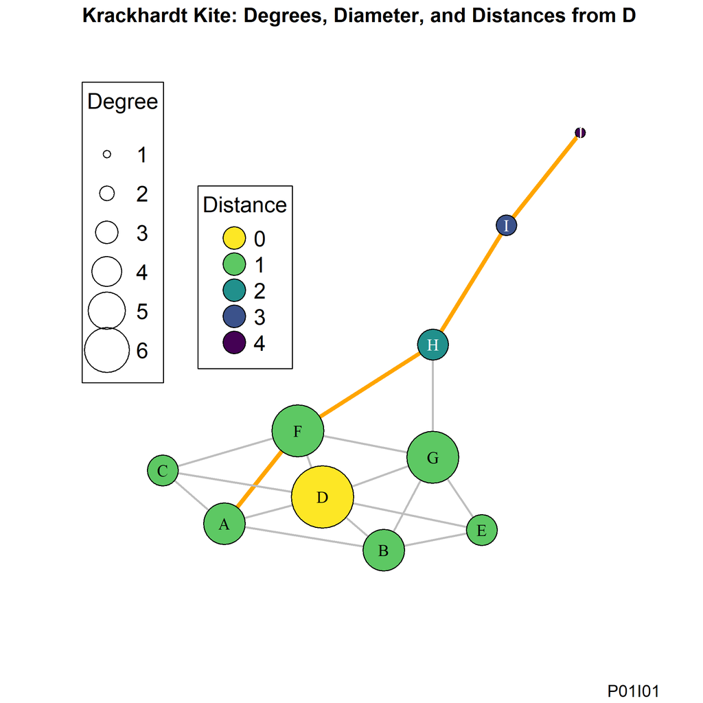

Figure 1.1 (P01I01) Krackhardt Kite

#### Code

**R**

```r
hh <- r_kite
#
# #Use Degrees of each node to indicate size
size_m <- 5L
size_hh <- degree(hh, mode = "all") * size_m
#
# #Distances of ALL Nodes from the Specified Node i.e. "D"
away_d <- distances(hh, v = V(hh)["D"], to = V(hh))
# #Get a Vector of same length with Maximum Unique Colors & accounting for 0 index
v_col_hh <- viridis(max(away_d) + 1, direction = -1)[away_d + 1]
v_lbl_col_hh <- c(rep("black", vcount(hh)-3), rep("white", 3))
#
# #Get Diameter Path
far_hh <- farthest_vertices(hh)$vertices
dia_hh <- shortest_paths(hh, from = V(hh)[far_hh[1]], to  = V(hh)[far_hh[2]], output = "both")
#
# #Edge color
e_col_hh <- rep("gray", ecount(hh))
e_col_hh[unlist(dia_hh$epath)] <- "orange"
# #Edge width
e_w_hh <- rep(2, ecount(hh))
e_w_hh[unlist(dia_hh$epath)] <- 4
# #Node color for the Path
#v_col_hh <- rep("gray", vcount(hh))
#v_col_hh[unlist(dia_hh$vpath)] <- "gold"
#
# #Color Legend
lgd_col_hh <- tibble(Text = unique(as.vector(away_d)), Fill = unique(v_col_hh)) |> arrange(Text)
lgd_ttl_col_hh <- "Distance"
# #Size Legend
lgd_size_hh <- sort(unique(size_hh))/size_m
lgd_ttl_size_hh <- "Degree"
#
ttl_hh <- "Krackhardt Kite: Degrees, Diameter, and Distances from D"
cap_hh <- "P01I01"
loc_png <- here("images", "P01I01-Kite.png")
#
if(FALSE | !file.exists(loc_png)) {
  png(filename = loc_png, width = q_png_w, height = q_png_h, units = "in", res = q_dpi)
  #dev.control('enable')
  plot(hh, vertex.size = size_hh, vertex.color = v_col_hh, vertex.label.color = v_lbl_col_hh,
       edge.color = e_col_hh, edge.width = e_w_hh)
  legend(x = "topleft", inset = 0.2, legend = lgd_col_hh$Text, pt.bg = lgd_col_hh$Fill,
         pch = 21, pt.cex = 3, cex = 1.3, title = lgd_ttl_col_hh)
  legend(x = "topleft", legend = seq.int(lgd_size_hh), pt.cex = lgd_size_hh,
         pch = 1, cex = 1.3, x.intersp = 1.5, y.intersp = 1.5, title = lgd_ttl_size_hh)
  title(main = ttl_hh, line = 3, adj = 0)
  title(sub = cap_hh, line = 4, adj = 1)
  P01 <- recordPlot()
  dev.off()
  assign(cap_hh, P01)
  rm(P01)
  #eval(parse(text = cap_hh))
}
```

### 1.4.12 Centrality

#### 1.4.12.1 Degree Centrality

- The degree of a vertex is the number connections (adjacent edges) for a node

##### R

**R**

```r
bb <- r_kite
# #Vector of each Vertex Degree: mode = c("all", "out", "in", "total")
degree(bb, mode = "all")
## A B C D E F G H I J
## 4 4 3 6 3 5 5 3 2 1
```

##### Python

**Python**

```python
pp = copy.deepcopy(y_kite)
# #Dictionary of each Vertex Degree by combining Two Lists
qq = dict(zip(pp.vs['name'], pp.degree(), strict = True))
#qq.keys()
#qq.values()
#print(qq.items())
print(qq)
## {'A': 4, 'B': 4, 'C': 3, 'D': 6, 'E': 3, 'F': 5, 'G': 5, 'H': 3, 'I': 2, 'J': 1}
for key, value in qq.items(): print(key + " : " + value.__str__())
## A : 4
## B : 4
## C : 3
## D : 6
## E : 3
## F : 5
## G : 5
## H : 3
## I : 2
## J : 1
```

#### 1.4.12.2 Closeness Centrality

- Closeness centrality measures how many steps is required to access every other vertex from a given vertex.
  - Normalized closeness centrality shows the inverse of the number of edges to all other nodes in the graph (e.g. a value of .5 means an average of two edges)

##### R

**R**

```r
bb <- r_kite
# #Vector of each Vertex Closeness: mode = c("all", "out", "in", "total")
closeness(bb, mode = "all", normalized = TRUE) |> round(3)
```

```
##     A     B     C     D     E     F     G     H     I     J
## 0.529 0.529 0.500 0.600 0.500 0.643 0.643 0.600 0.429 0.310
```

##### Python

**Python**

```python
pp = copy.deepcopy(y_kite)
# #Dictionary of each Vertex Closeness by combining Two Lists
qq = [round(i, 3) for i in pp.closeness()]
ss = dict(zip(pp.vs['name'], qq, strict = True))
print(ss)
## {'A': 0.529, 'B': 0.529, 'C': 0.5, 'D': 0.6, 'E': 0.5, 'F': 0.643, 'G': 0.643, 'H': 0.6, 'I': 0.429, 'J': 0.31}
for key, value in ss.items(): print(key + " : " + value.__str__())
## A : 0.529
## B : 0.529
## C : 0.5
## D : 0.6
## E : 0.5
## F : 0.643
## G : 0.643
## H : 0.6
## I : 0.429
## J : 0.31
```

#### 1.4.12.3 Betweenness Centrality

- Betweenness centrality shows the number of shortest paths a node is on between pairs of other nodes.
  - If multiple shortest paths between two nodes exist the betweenness is shared among all the intermediate nodes

##### R

**R**

```r
bb <- r_kite
# #Betweenness returns a 'communities' object
ii <- cluster_edge_betweenness(bb)
attributes(ii)
```

```
## $names
## [1] "removed.edges"    "edge.betweenness" "merges"           "bridges"          "modularity"
## [6] "membership"       "names"            "vcount"           "algorithm"
##
## $class
## [1] "communities"
```

```r
str(ii)
## Class 'communities'  hidden list of 9
##  $ removed.edges   : num [1:18] 17 15 16 8 14 11 1 3 2 4 ...
##  $ edge.betweenness: num [1:18] 16 3.5 7 3 3.42 ...
##  $ merges          : num [1:9, 1:2] 10 7 12 6 13 14 15 8 11 9 ...
##  $ bridges         : num [1:9] 19 18 17 15 14 11 9 4 2
##  $ modularity      : num [1:10] -0.11574 -0.06327 -0.03086 0.00617 0.03858 ...
##  $ membership      : num [1:10] 1 2 1 2 2 1 2 3 4 4
##  $ names           : chr [1:10] "A" "B" "C" "D" ...
##  $ vcount          : int 10
##  $ algorithm       : chr "edge betweenness"
#
# #Modularity
modularity(ii)
```

```
## [1] 0.1805556
```

```r
#
# #Group Sizes
sizes(ii)
## Community sizes
## 1 2 3 4
## 3 4 1 2
#
# #Groups
setNames(ii$membership, nm = ii$names)
## A B C D E F G H I J
## 1 2 1 2 2 1 2 3 4 4
#
# #First Group
ii[[1]]
```

```
## [1] "A" "C" "F"
```

##### Python

**Python**

```python
pp = copy.deepcopy(y_kite)
# #Betweenness returns a 'communities' object
qq = [round(i, 3) for i in pp.betweenness()]
print(qq)

#cl = ig.Clustering(pp.vs()['group'])
#print(cl)
#pp.modularity(membership=cl)
#ig.VertexClustering(pp, pp.vs["group"])

# #ForLater
## [0.833, 0.833, 0.0, 3.667, 0.0, 8.333, 8.333, 14.0, 8.0, 0.0]
```

#### 1.4.12.4 Eigenvector Centrality or Pagerank

- Eigenvector centrality or Pagerank scores correspond to the values of the first eigenvector of the graph adjacency matrix; these scores may, in turn, be interpreted as arising from a reciprocal process in which the centrality of each actor is proportional to the sum of the centralities of those actors to whom he or she is connected.
  - In general, vertices with high eigenvector centralities are those which are connected to many other vertices which are, in turn, connected to many others.
  - It is a recursive measure of centrality, measuring each node by not only the number of connections it has, but weighting that metric by how many connections its connections have, which are in turn weighted by their connections etc.

##### R

**R**

```r
bb <- r_kite
# #List of Eigenvector and Eigenvalue Score
ii <- eigen_centrality(bb)
#
# #Eigenvector of each Vertex
ii$vector |> round(3)
```

```
##     A     B     C     D     E     F     G     H     I     J
## 0.732 0.732 0.594 1.000 0.594 0.827 0.827 0.407 0.100 0.023
```

```r
#
# #Eigenvalue Score
ii$value
```

```
## [1] 4.306404
```

##### Python

**Python**

```python
pp = copy.deepcopy(y_kite)

# #List of Eigenvector
qq = [round(i, 3) for i in pp.eigenvector_centrality()]
ss = dict(zip(pp.vs['name'], qq, strict = True))
print(ss)
## {'A': 0.732, 'B': 0.732, 'C': 0.594, 'D': 1.0, 'E': 0.594, 'F': 0.827, 'G': 0.827, 'H': 0.407, 'I': 0.1, 'J': 0.023}
for key, value in ss.items(): print(key + " : " + value.__str__())

# #Eigenvalue Score - #ForLater
## A : 0.732
## B : 0.732
## C : 0.594
## D : 1.0
## E : 0.594
## F : 0.827
## G : 0.827
## H : 0.407
## I : 0.1
## J : 0.023
```

#### 1.4.12.5 Degree & Eigenvalue

- Residual of Simple Linear Regression can be used to size the nodes in our network. This may identify nodes which are connected to only a few nodes, which are “important” i.e. they have high eigenvector centrality.
- #ForLater - Python igraph

##### R

**R**

```r
bb <- r_kite
ii_deg <- degree(bb, mode = "all")
ii_egn <- eigen_centrality(bb)$vector
# #Tibble
ii <- tibble(Vertices = names(ii_deg), Degree = ii_deg, Eigen = ii_egn)
# #Regression
ii_res <- lm(Eigen ~ Degree, data = ii)$residuals |> round(7)
# #Add Residuals
ii |> add_column(Residual = ii_res) |> mutate(Size = abs(Residual)*100)
```

```
## # A tibble: 10 × 5
##    Vertices Degree  Eigen Residual  Size
##    <chr>     <dbl>  <dbl>    <dbl> <dbl>
##  1 A             4 0.732    0.0677  6.77
##  2 B             4 0.732    0.0677  6.77
##  3 C             3 0.594    0.132  13.2
##  4 D             6 1       -0.0687  6.87
##  5 E             3 0.594    0.132  13.2
##  6 F             5 0.827   -0.0399  3.99
##  7 G             5 0.827   -0.0399  3.99
##  8 H             3 0.407   -0.0552  5.52
##  9 I             2 0.0999  -0.160  16.0
## 10 J             1 0.0232  -0.0350  3.50
```

### 1.4.13 Cliques

- Cliques are sets of nodes which are all connected to one another.
  - To be included in a clique, a node must be tied to all other nodes in the clique.
  - A k-core is a group where nodes have k edges within the group.
    - The k-core of graph is a maximal subgraph in which each vertex has at least degree k.
    - The coreness of a vertex is k if it belongs to the k-core but not to the (k+1)-core.
    - Two nodes with coreness of 3 may not be connected at all and may be in separate k-cores.
  - NOTE: Directed graphs will be considered as Undirected ones for Cliques calculation

**R**

```r
bb <- r_kite
# #Max Cliques with Lengths
summary(max_cliques(bb))[, 1]
```

```
## [1] "2" "2" "3" "4" "3" "3" "4"
```

```r
#
# #Largest Cliques
largest_cliques(bb)
## [[1]]
## + 4/10 vertices, named, from d353321:
## [1] D G E B
##
## [[2]]
## + 4/10 vertices, named, from d353321:
## [1] D A F C
#
# #Coreness
coreness(bb)
## A B C D E F G H I J
## 3 3 3 3 3 3 3 2 1 1
```

#### Plot

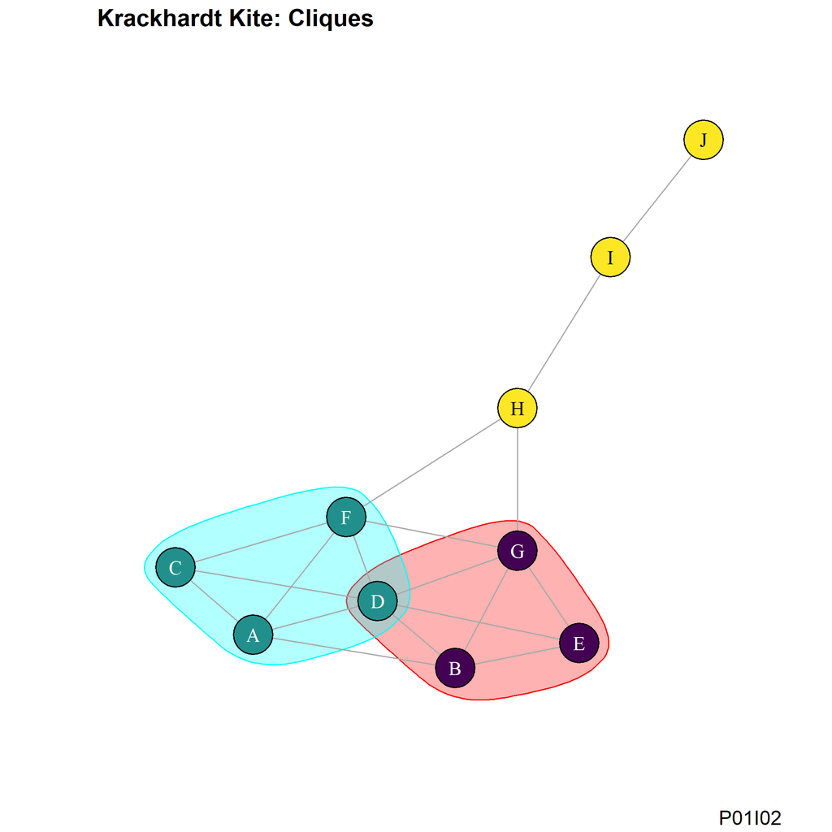

Figure 1.2 (P01I02) Krackhardt Kite: Cliques

#### Code

**R**

```r
hh <- r_kite
#
# #Get Largest Cliques
cliq_hh <- largest_cliques(hh)
# #Color Cliques
pal_hh <- viridis(length(cliq_hh) + 1) #Palette
v_col_hh <- rep(last(pal_hh), vcount(hh))
v_col_hh[cliq_hh[[1]]] <- pal_hh[1]
v_col_hh[cliq_hh[[2]]] <- pal_hh[2]
#
# #Text Label Color
v_lbl_col_hh <- c(rep("black", vcount(hh)))
v_lbl_col_hh[cliq_hh[[1]]] <- "white"
v_lbl_col_hh[cliq_hh[[2]]] <- "white"
#
ttl_hh <- "Krackhardt Kite: Cliques"
cap_hh <- "P01I02"
loc_png <- here("images", "P01I02-Kite-Cliques.png")
#
if(FALSE | !file.exists(loc_png)) {
  png(filename = loc_png, width = q_png_w, height = q_png_h, units = "in", res = q_dpi)
  #dev.control('enable')
  plot(hh, vertex.color = v_col_hh, vertex.label.color = v_lbl_col_hh, mark.groups = cliq_hh)
  title(main = ttl_hh, line = 3, adj = 0)
  title(sub = cap_hh, line = 4, adj = 1)
  P01 <- recordPlot()
  dev.off()
  assign(cap_hh, P01)
  rm(P01)
  #eval(parse(text = cap_hh))
}
```

## 1.5 Community Detection & Modularity

### R

**R**

```r
bb <- r_kite
# #Betweenness Centrality: Slow
btw <- cluster_edge_betweenness(bb)
# #Modularity
modularity(btw) |> round(3)
```

```
## [1] 0.181
```

```r
# #Group Sizes
sizes(btw)
## Community sizes
## 1 2 3 4
## 3 4 1 2
# #Groups
setNames(btw$membership, nm = btw$names)
## A B C D E F G H I J
## 1 2 1 2 2 1 2 3 4 4
#
# #Walktrap Algorithm
walk <- cluster_walktrap(bb)
# #Modularity
modularity(walk) |> round(3)
```

```
## [1] 0.125
```

```r
# #Group Sizes
sizes(walk)
## Community sizes
## 1 2 3
## 2 7 1
# #Groups
setNames(walk$membership, nm = walk$names)
## A B C D E F G H I J
## 2 2 2 2 2 2 2 3 1 1
#
# #Fast Greedy Algorithm
greed <- cluster_fast_greedy(bb)
# #Modularity
modularity(greed) |> round(3)
```

```
## [1] 0.222
```

```r
# #Group Sizes
sizes(greed)
## Community sizes
## 1 2 3
## 3 4 3
# #Groups
setNames(greed$membership, nm = greed$names)
## A B C D E F G H I J
## 1 2 1 2 2 1 2 3 3 3
```

### Python

## 1.6 Community Detection Algorithms

### Plot

[figure not shown]

Figure 1.3 (P01I03) Krackhardt Kite: Communities

### Code

**R**

```r
hh <- r_kite
hh_b <- cluster_edge_betweenness(hh)
hh_w <- cluster_walktrap(hh)
hh_g <- cluster_fast_greedy(hh)
#
#ttl_hh <- "Krackhardt Kite: Communities"
ttl_hh_b <- "Kite: Betweenness"
ttl_hh_w <- "Kite: Walktrap"
ttl_hh_g <- "Kite: Fast Greedy"
cap_hh <- "P01I03"
loc_png <- here("images", "P01I03-Kite-Communities.png")
#
if(FALSE | !file.exists(loc_png)) {
  png(filename = loc_png, width = q_png_w_w, height = q_png_w_h, units = "in", res = q_dpi_w)
  #dev.control('enable')
  def_par <- par(no.readonly = TRUE) #Save Default
  par(mfrow = c(2, 3), mar = c(0,0,0,0))
  plot(x = hh_b, y = hh)
  title(main = ttl_hh_w, line = -2, adj = 0.5)
  plot(x = hh_w, y = hh)
  title(main = ttl_hh_b, line = -2, adj = 0.5)
  plot(x = hh_g, y = hh)
  title(main = ttl_hh_g, line = -2, adj = 0.5)
  plot_dendrogram(x = hh_b, cex = 2)
  plot_dendrogram(x = hh_w, cex = 2)
  plot_dendrogram(x = hh_g, cex = 2)
  par(def_par)  #Reset Default
  title(sub = cap_hh, line = 4, adj = 1)
  P01 <- recordPlot()
  dev.off()
  #par(mfrow = c(1, 1)) #Default
  assign(cap_hh, P01)
  rm(P01)
  #eval(parse(text = cap_hh))
}
```

## Validation

**R**

```r
# #SUMMARISED Packages and Objects (BOOK CHECK)
f_()
```

```
## [1] ""
```

```r
#
difftime(Sys.time(), q_start)
## Time difference of 36.03882 secs
```

# 2 NLP Theory

## 2.1 Overview

**Definition 2.1** Data are the facts and figures collected, analysed, and summarised for presentation and interpretation.

**Definition 2.2** Structured data is where you have some kind of a high level of organization. e.g. relational databases, spreadsheets etc. It depends on a data model i.e. a model of data types and how they will be stored, accessed, and processed.

**Definition 2.3** Unstructured data does not come with the predefined data model. It can be images, videos, text and might be a combination of these.

**Definition 2.4** Social media refers to a set of computer-network based tools that support social interaction between users. The term is often used to contrast with more traditional media such as television and books that deliver content to mass populations but do not facilitate the creation or sharing of content by users. Social media is about transforming broadcast (one-to-many) into dialog (many-to-many).

- A social media service can be effectively categorized by 6 key features
  - Size of producer and consumer population
    - Users are producers one moment and consumers the next. However, the differentiation is still important
  - Pace of interaction
    - Asynchronous systems like email or discussion forums presume a staccato pattern of interaction.
      - They are asynchronous, messages are labeled with an associated address or username, typically, with a single author, and other authors can reply to these messages and reply to other replies creating conversation “threads”.
    - Synchronous systems, like chat require that partners interact at the same time. Although they require temporal coordination, they can create a richer environment for interaction as participants quickly react and adjust in near real time.
  - Genre of basic elements - Text message, Webpage, Video etc.
  - Control of basic elements
    - Repeated interaction is perhaps the single most important factor in encouraging cooperation. If individuals are not likely to interact in the future, there is a huge temptation to behave selfishly.
  - Types of connections - undirected (Friendship), directed links (Follower)
  - Retention of content
    - Ironically, digital culture may have less durability than pre-digital culture.

**Definition 2.5** A special subset of networks are social networks which are created whenever people interact, directly or indirectly, with other people, institutions, and artifacts.

**Definition 2.6** Using network analysis, we can visualize complex sets of relationships as maps (i.e., graphs or sociograms) of connected symbols and calculate precise measures of the size, shape, and density of the network as a whole and the positions of each element and group of elements within it.

**Definition 2.7** Social network analysis is the application of the broader field of network science to the study of human relationships and connections.

- We can use social network analysis to explore and visualize patterns found within collections of linked entities that include people.
- Relationships are the building blocks of the social world. Each set of relationships combine to create emergent patterns of connections among people, groups, and things. The focus of social network analysis is between, not within, people.
- Network analysis shifts the focus of analysis to the bonds between individuals in addition to the internal qualities and abilities of individuals.
  - This change in focus from attribute data to relational data dramatically affects how data are collected, represented, and analyzed.
  - Social network analysis complements methods that focus more narrowly on individuals, adding a critical dimension that captures the connective tissue of societies and other complex interconnections.
  - The position or location of a person or ‘node’ or ‘vertex’ in relation to all the others is a primary concern of social network analysis.
    - Many network explanations look for causes of outcomes in the patterns of connections around an individual instead of their personal characteristics.
    - ‘Know who’ is often more important in network explanations than ‘know how’.
    - Network approaches observe that different people in similar social positions often act in similar ways, even if they have different backgrounds.
    - Positions within networks may be as significant a factor as any aspect of the people who occupy them. Network analysis argues that explanations about the success or failures of organizations are often to be found in the structure of relationships that limit or provide opportunities for interaction.

## 2.2 Network Data Representation

- Because network data differ from attribute data, a different way to represent it is used.
  - With attribute data, it is common to create a data matrix where each row represents an individual and each column represents their characteristics, behaviors, or answers to survey questions.
  - A modified approach is used to represent relational data. Like attribute matrices, each row represents an individual in the network. However, unlike attribute matrices, each column represents other individuals.
    - Diagonal is generally zero because a person does not point to themselves
    - Undirected network would be a symmetric matrix because the connection would be reciprocated
- Network matrices are powerful forms of representation that lend themselves to efficient mathematical manipulation for those inclined.
  - However, they can also become quite large and challenging to navigate, particularly when networks are relatively “sparse” with few connections and many items.
- An alternative to the matrix data format that is a more efficient representation of a network is called an edge list.
  - It is simply a list of all edges in the network.
  - Individuals in the Vertex1 column “point to” those in the Vertex2 column.
  - Unless data describing the value of each edge are provided in additional columns, the network is implied to be a binary one (not weighted).
  - Edge lists are “efficient” in that they only record a row of data for each connection that does exist in a network, rather than store a “zero” for each possible connection that does not exist.
- The final method for representing networks is through network graphs.
  - These show all the nodes and connections in a graphical representation.
  - Network graphs can lead to insights that are hard to identify in tabular data, particularly when large networks are presented.
  - However, many network graphs require significant preparation to assure that they are readable.

## 2.3 Types of Networks

- Egocentric, partial, and full networks
  - It is often useful to consider social networks from an the point of view of an individual member.
  - Network analysts call the individual that is the focus of attention ’ego’ and the people they are connected to ’alters’.
  - Egocentric networks only include individuals who are connected to a specified ego.
  - More generally, egocentric networks can extend out any number of ‘degrees’ from an ego.
    - The basic ‘1-degree’ ego network consists of the ego and their alters.
    - The ‘1.5-degree’ ego network extends the 1-degree network by including connections between all of the alters.
    - The ‘2-degree’ ego network extends the 1.5-degree network by including all of the alters of the alters (i.e., friends of friends), some of whom may not be connected to the ego.
    - These three sizes of ego networks allow you to look at increasingly larger, but still ‘local’ neighborhoods around a particular individual in a social network.
- A ‘full’ or ‘complete’ network contains the subset of people or entities who match some interest or attribute and includes information about the set of connections among them all.
  - All the ‘egos’ in a full network are treated equally, none is assumed to be the ‘ego’ of the network, although analysis of these networks will reveal that some people are more strategically located in the network than others.
  - Analysts create more selective sub-networks by selecting a sample or slice of the larger complete network.
- Unimodal, multimodal, and affiliation networks
  - Standard networks that connect the same type of entityare called unimodal networks because they include one type (i.e., mode) of vertex.
  - They connect users to users or they connect documents to documents, but they do not include both users and documents.
  - However, networks can include different types of vertices creating multimodal networks.
    - In many cases, these multimodal networks have to be transformed into simpler unimodal networks to perform meaningful network analysis, as most network metrics are designed for unimodal networks.
  - A common type of multimodal network is a bimodal network with exactly two types of vertices.
    - Data for these networks often include individuals and some event, activity, or content with which they are affiliated, creating an affiliation network.
    - For example, an affiliation network may connect users with the wiki pages they have edited. People are affiliated with pages.
    - In this network, no two users would directly connect to each other.
    - Likewise, no two pages would directly connect to each other.
    - Pages only link to people (i.e., editors).
    - Bimodal affiliation networks can be transformed into two separate unimodal networks: a ‘user edits page’ network can be converted into a user-to-user network and an page to page network.
    - The user-to-user network connects people based on their indirect links to one another through edits to a common page. For example, in a wiki co-edit affiliation network Derek and Marc would be strongly connected because they both edit many of the same wiki pages.
    - In contrast, a Page to Page network connects Pages based on the number of shared editors. For example, a pair of wiki pages would be closely connected if many people edited both of the pages.
    - More generally, this approach can be used to relate objects of all types (e.g., books, photos, and audio recordings) based on behavior of the users (e.g., purchasing or reading habits) and their preferences (e.g., ratings).
    - Affiliation networks are the raw material of many systems that recommend items of interest, such as ‘Customers Who Bought This Item Also Bought’ feature.

## 2.4 Network analysis Metrics

**Definition 2.8** Some pairs of people are not directly connected. When a third person bridges a connection, we can think of that person as a broker, a ’bridge’ or a ‘connector’. When that person is missing, we can think of the gap as a ’structural hole’, a place in which there is a missing connector.

### 2.4.1 Density

**Definition 2.9** Density captures how connected a set of vertices are by calculating the percentage of connections that are observed from maximum possible count if everyone connected to everyone.

- Density is an aggregate network metric used to describe the level of interconnectedness among a set of vertices.
  - Density is a count of the number of relationships observed to be present in a network divided by the total number of possible relationships that could be present.
  - It is a quantitative way to capture important sociological ideas like cohesion, solidarity, and membership.

### 2.4.2 Centrality

- Centralization is an aggregate metric that characterizes the amount to which the network is centered on one or just a few important nodes.
  - Centralized networks have many edges that emanate from a few important vertices, whereas decentralized networks have many vertices with many interconnections.
  - Networks with high levels of centralization are likely to be more hierarchical, with a few people playing hub roles.
- Studies typically show that people are connected to others who are similar to themselves on core attributes like income, education level, religious affiliation, and age.

**Definition 2.10** Centrality measures capture how ‘important’ (central) a vertex is within the network based on some objective criteria. Some people sit at the edge or periphery of their networks, whereas others are firmly at the center, connected to many of the other most connected people.

- Degree centrality is a simple count of the total number of connections linked to a vertex.
  - It can be thought of as a kind of popularity measure, but a crude one that does not recognize a difference between quantity and quality.
  - It does not differentiate between a link to the CEO and a link to the most recent trainee.
  - Degree is the measure of the total number of edges connected to a particular vertex.
  - For directed networks where relationships have an origin and a destination rather than have mutual connections, there are two measures of degree: in-degree and out-degree.
    - In-degree is the number of connections that point inward at a vertex.
    - Out-degree is the number of connections that originate at a vertex and point outward to other vertices.
- Betweenness centrality:
  - The notion of connection paths is central to the study of networks.
  - Perhaps one of the most natural questions to ask about any two people in a network it is ’How far apart are they’
  - The distance between people who are not neighbors is measured by the smallest number of neighbor-to-neighbor hops from one to connect to the other.
    - For $A \to B \to C:$ C is at a distance 2 from A.
  - The shortest path between two people is called the ’geodesic distance’ and is used in many centrality metrics.
  - Betweenness centrality is a measure of how often a given vertex lies on the shortest path between two other vertices.
    - This can be thought of as a kind of ‘bridge’ score, a measure of how much removing a person would disrupt the connections between other people in the network.
    - A ’structural hole’ is a term for recognizing a missing bridge.
    - Individuals who bridge structural holes within their organizations are promoted faster than others.
- Closeness centrality:
  - Closeness centrality measures position of each individual in the network via a different perspective from the other network metrics, capturing the average distance between each vertex and every other vertex in the network.
  - Assuming that vertices can only pass messages to or influence their existing connections, a low closeness centrality means that a person is directly connected or ‘just a hop away’ from most others in the network.
  - In contrast, vertices in very peripheral locations may have high closeness centrality scores, indicating the high number of hops or connections they need to take to connect to distant others in the network.
  - Think of closeness, paradoxically, as a ‘distance’ score. People with high ‘closeness’ centrality scores have many personal connections that they must travel to reach many other people in the network.
- Eigenvector centrality:
  - Eigenvector centrality is a more sophisticated view of centrality: a person with few connections could have a very high eigenvector centrality if those few connections were to very well-connected others.
    - Eigenvector centrality allows for connections to have a variable value, so that connecting to some vertices has more benefit than connecting to others.
    - The PageRank algorithm used by Google is a variant of Eigenvector Centrality, primarily used for directed networks.
- Clustering coefficient:
  - The clustering coefficient metric differs from measures of centrality. It is more akin to the density metric for whole networks, but focused on egocentric networks.
  - Specifically, the clustering coefficient is a measure of the density of the 1.5-degree egocentric network for each vertex.
  - When these connections are dense, the clustering coefficient is high.
  - If your ‘friends’ (alters) all know each other, you have a high clustering coefficient.
  - If your ‘friends’ (alters) do not know each other, then you have a low clustering coefficient.
  - People have different measures for their clustering coefficient depending on the ways they cultivate connections to others and the environments they are in.

## 2.5 Groups and Clusters

- In a network perspective, people maintain many relationships and are potentially members in many loosely defined groups and clusters.
- From a network perspective, a group is a collection of vertices.
- Relatively more cohesive or densely connected sets of vertices form regions, also called clusters, that may reflect the existence of groups.
- Two people within a network may sometimes share a pattern of connection to other people, even if they do not connect to the same people. These secondary patterns of connection are a distinctive feature of network analysis approaches: networks are as much about the attributes and patterns of connection among neighbors as they are about the attributes and connections of any individual.

## 2.6 Extract data from Twitter

“ForLater”

## 2.7 Apr-17

- Social Media Analytics
  - Relationships
    - Standing relationships: by virtue of membership in a family or other social group
      - You follow twitter account of a famous person
    - Ad hoc relationships: by virtue of your actions or activities
      - You like a tweet of a famous person
  - Media - Opportunities to create and exchange content
    - It is participatory, conversational and relationship oriented
  - Analytics
    - Information resulting from the systematic analysis of data or statistics
    - informative and insightful product
- Forms
  - Descriptive - What happened
  - Diagnostic - Why it happened
  - Predictive - What will happen
  - Prescriptive - What should be done
- Big Data
  - volume, velocity, variety, and veracity (relevance, quality)
- Nodes and Ties

## 2.8 Apr-24

- Relation is not the same thing as tie!
- Peripheral Nodes
- isolated, dyad, triad,
- Connected Components
  - Separated from the rest of a Network
- Information broker, boundary spanner
  - connects disconnected components- connects internal ones (Information broker), connects external ones (boundary spanner)
- What factors account for tie formation
  - Propinquity (physical proximity)
  - Homophily - Preference towards those similar to themselves
    - Induced - Group composition produce homophily
    - Choice - People seek others similar to themselves, irrespective of their groups
  - Transitivity: A to B, A to C : overtime B to C
- Social Network Types: Based on Ties - Slide 12
  - Directed
  - Undirected
  - reciprocated
  - unreciprocated
- Number of entities
  - one mode
  - two mode - actors and events - slide 17 16:20
- Is group a network - 16:30 slide 19
  - Group is one way of developing network ties
- Representation - Matrix, Edge Lists, Sociogram (Network Graph)
- Matrix - 16:35 slide 21 - check details - 16:40
  - Adjacency Matrix
  - Affilition Matrix
    - Group to Group
- Topologies
  - Star or Wheel
  - Y
  - Line or Chain
  - Circle
  - Fully Connected
- What does the colour signify - 16:48
  - Later
- Which topology provides most satisfaction
  - cannot be fully-connected- information overload
  - no star - someone else is controlling information flow to you
  - circle -
- 16:50 For the simple communication task, fewest messages and least amount of time to complete, most efficient topologies will be …
  - “ForLater” two of five - Star &
- Break 16:55 - 17:10
- Two demos

17:55

- Ego Metrics
  - Centrality: Connectedness 34 : Ego to Ego
    - Degree
    - Betweenness
    - Closeness
    - Eigen-vector
  - Clustering Coefficient: Structural equivalence: Ego having similar ties
- Krackhardt Kite - K Network

## 2.10 May-15

- 15:45 - Group by connected components
- Group by cluster
- Sub-group analysis - 16:20 29

## Validation

# 3 ANN

## Validation

# References

# Glossary

## THEOREMS

## DEFINITIONS

1.1: Network

A network is a collection of entities and their relationships to one another. The entities that are connected are called nodes (vertices). The connections between the vertices are called edges (links).

2.1: Data

Data are the facts and figures collected, analysed, and summarised for presentation and interpretation.

2.2: Data-Structured

Structured data is where you have some kind of a high level of organization. e.g. relational databases, spreadsheets etc. It depends on a data model i.e. a model of data types and how they will be stored, accessed, and processed.

2.3: Data-Unstructured

Unstructured data does not come with the predefined data model. It can be images, videos, text and might be a combination of these.

2.4: Social-Media

Social media refers to a set of computer-network based tools that support social interaction between users. The term is often used to contrast with more traditional media such as television and books that deliver content to mass populations but do not facilitate the creation or sharing of content by users. Social media is about transforming broadcast (one-to-many) into dialog (many-to-many).

2.5: Social-Networks

A special subset of networks are social networks which are created whenever people interact, directly or indirectly, with other people, institutions, and artifacts.

2.6: Network-Analysis

Using network analysis, we can visualize complex sets of relationships as maps (i.e., graphs or sociograms) of connected symbols and calculate precise measures of the size, shape, and density of the network as a whole and the positions of each element and group of elements within it.

2.7: Social-Network-Analysis

Social network analysis is the application of the broader field of network science to the study of human relationships and connections.

2.8: bridge-hole

Some pairs of people are not directly connected. When a third person bridges a connection, we can think of that person as a broker, a ’bridge’ or a ‘connector’. When that person is missing, we can think of the gap as a ’structural hole’, a place in which there is a missing connector.

2.9: Density

Density captures how connected a set of vertices are by calculating the percentage of connections that are observed from maximum possible count if everyone connected to everyone.

2.10: Centrality

Centrality measures capture how ‘important’ (central) a vertex is within the network based on some objective criteria. Some people sit at the edge or periphery of their networks, whereas others are firmly at the center, connected to many of the other most connected people.

## ERRORS

# END

Goto FIRST